# Assignment 2

Catherine Saint

8/25/2020

```r
library(tidycensus)
library(tidyverse)
```

```r
library(ggplot2)
tract_data <- read_csv("tractLosAngelesCA2018.csv")
attach(tract_data)
```

### Assignment Instructions

For each continuous variable in your dataset, calculate the sample mean, the sample standard deviation, the 95-percent confidence interval for the population mean, and the interquartile range. Create a histogram to illustrate the distribution of each variable and describe the distribution in a sentence or two. For each categorical variable in your dataset, calculate the 95-percent confidence interval for the proportion of the population in each category.

#### Reminder of my variables from Assignment 1:

1. Median Age (continuous) : med_ageE
2. Part of the total population unemployed in civilian labor force (age 16 years and above) (continuous): pct_unemp_labor
3. Part of the total population who are high school graduates (or equivalent) in labor force (continuous): pct_hs_grad
4. Majority race of the population (categorical) : maj_race_tract
5. Whether the majority of the population is foreign born or not(categorical): maj_foreign

## Distribution of Continuous Variables

1. Median Age: med_ageE

```r
summary(med_ageE)
```

```
##    Min. 1st Qu.  Median    Mean 3rd Qu.    Max.    NA's
##   18.30   32.40   36.40   37.07   41.30   67.10      22
```

```r
sd(med_ageE, na.rm = TRUE)
```

```
## [1] 6.585941
```

```r
paste("The sample standard deviation for the median age is",
      prettyNum(sd(med_ageE, na.rm = TRUE), digits = 3), "years.")
```

```
## [1] "The sample standard deviation for the median age is 6.59 years."
```

Notice that I use the code (na.rm = TRUE) throughout to rid my dataset of N/A values. Now that I have the summary data, I want to find the confidence interval.

```r
pop_mean <- t.test(med_ageE)
pop_mean
```

```
##
##  One Sample t-test
##
## data:  med_ageE
## t = 271.37, df = 2323, p-value < 2.2e-16
## alternative hypothesis: true mean is not equal to 0
## 95 percent confidence interval:
##  36.80525 37.34105
## sample estimates:
## mean of x
##  37.07315
```

```r
paste("The 95-percent confidence interval for the population mean is",
      prettyNum(pop_mean$conf.int[1], digits = 3), "to",
      prettyNum(pop_mean$conf.int[2], digits = 3), "years.")
```

```
## [1] "The 95-percent confidence interval for the population mean is 36.8 to 37.3 years."
```

Now, I want to see the distribution through a histogram. I’m also going to add code that allows me to display the summary statistics calculated above onto the histogram. I changed the digits value from 0 to 3 to display the significant digits. Otherwise, my confidence interval for median age would be rounded to the following: 37 years to 37 years (which is not that helpful).

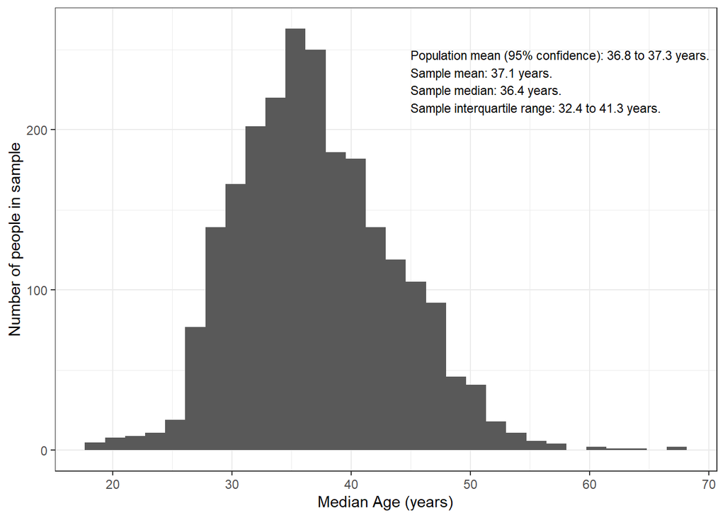

```r
hist <- ggplot(tract_data, aes(x = med_ageE)) + geom_histogram()
hist +
  theme_bw() +
  scale_x_continuous(name = "Median Age (years)") +
  scale_y_continuous(name = "Number of people in sample") +
  annotate ("text", x = 45, y = 250, size = 3,
            label = paste ("Population mean (95% confidence):",
                           prettyNum(pop_mean$conf.int[1], digits = 3),
                           "to",
                           prettyNum(pop_mean$conf.int[2], digits = 3),
                           "years.",
                           "\nSample mean:",
                           prettyNum(mean(med_ageE, na.rm = TRUE), digits = 3), "years.",
                           "\nSample median:",
                           prettyNum(median(med_ageE, na.rm = TRUE), digits = 3), "years.",
                           "\nSample interquartile range:",
                           prettyNum(quantile(med_ageE, na.rm = TRUE)["25%"], digits = 3),
                           "to",
                           prettyNum(quantile(med_ageE, na.rm = TRUE)["75%"], digits = 3),
                           "years."),
            hjust = 0, vjust = 1)
```

From the histogram, I am able to deduce that the distrubution of data is relatively normal, with a slightly positive, right-skew. The median value is less than the corresponding mean value, because there are a greater number of outliers within the older population, slightly affecting the mean value.

Next, I am going to use the same code for my other two continuous variables - a huge advantage of using R is copying and pasting code!

2. Part of the total population unemployed in civilian labor force (age 16 years and above): pct_unemp_labor

```r
summary(pct_unemp_labor)
```

```
##    Min. 1st Qu.  Median    Mean 3rd Qu.    Max.    NA's
## 0.00000 0.02385 0.03316 0.03550 0.04508 0.20000      19
```

```r
sd(pct_unemp_labor, na.rm = TRUE)
```

```
## [1] 0.01714264
```

```r
paste("The sample standard deviation for the unemployment percentage of the total population is",
      prettyNum(sd(med_ageE, na.rm = TRUE), digits = 3), "percent.")
```

[output not shown]

```r
pop_mean <- t.test(pct_unemp_labor)
pop_mean
```

```
##
##  One Sample t-test
##
## data:  pct_unemp_labor
## t = 99.899, df = 2326, p-value < 2.2e-16
## alternative hypothesis: true mean is not equal to 0
## 95 percent confidence interval:
##  0.03480405 0.03619779
## sample estimates:
##  mean of x
## 0.03550092
```

```r
paste("The 95-percent confidence interval for the population mean is",
      prettyNum(pop_mean$conf.int[1], digits = 3), "to",
      prettyNum(pop_mean$conf.int[2], digits = 3), "percent.")
```

```
## [1] "The 95-percent confidence interval for the population mean is 0.0348 to 0.0362 percent."
```

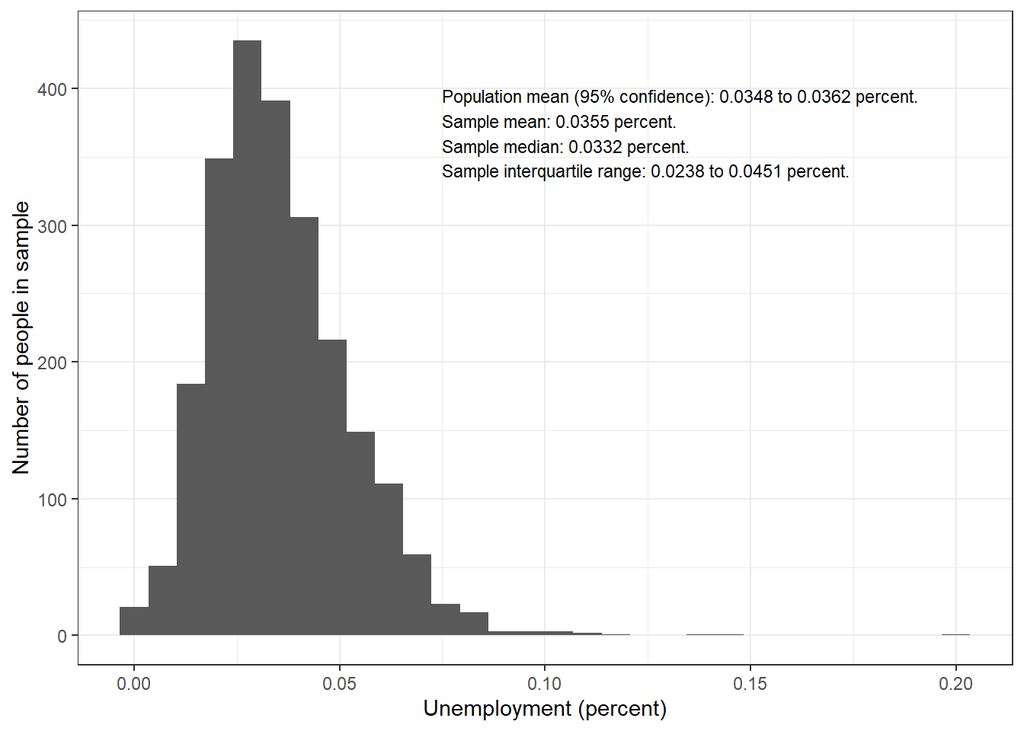

```r
hist <- ggplot(tract_data, aes(x = pct_unemp_labor)) + geom_histogram()
hist +
  theme_bw() +
  scale_x_continuous(name = "Unemployment (percent)") +
  scale_y_continuous(name = "Number of people in sample") +
  annotate ("text", x = 0.075, y = 400, size = 3,
            label = paste ("Population mean (95% confidence):",
                           prettyNum(pop_mean$conf.int[1], digits = 3),
                           "to",
                           prettyNum(pop_mean$conf.int[2], digits = 3),
                           "percent.",
                           "\nSample mean:",
                           prettyNum(mean(pct_unemp_labor, na.rm = TRUE), digits = 3), "percent.",
                           "\nSample median:",
                           prettyNum(median(pct_unemp_labor, na.rm = TRUE), digits = 3), "percent.",
                           "\nSample interquartile range:",
                           prettyNum(quantile(pct_unemp_labor, na.rm = TRUE)["25%"], digits = 3),
                           "to",
                           prettyNum(quantile(pct_unemp_labor, na.rm = TRUE)["75%"], digits = 3),
                           "percent."),
            hjust = 0, vjust = 1)
```

The distrubution of unemployment is similar to my Median Age variable in that it is relatively normal, with a slightly positive, right-skew. The median value is less than the corresponding mean value, because there are a greater number of outliers located along our x axis, where unemployment percentage increases.

3. Part of the total population who are high school graduates (or equivalent) in labor force over (age 16 years and above) (continuous): pct_hs_grad

```r
summary(pct_hs_grad)
```

```
##    Min. 1st Qu.  Median    Mean 3rd Qu.    Max.    NA's
## 0.00000 0.05694 0.08669 0.08405 0.10993 1.00000      19
```

```r
sd(pct_hs_grad, na.rm = TRUE)
```

```
## [1] 0.04252418
```

```r
paste("The sample standard deviation for the percent of highschool graduates (as a maximum educational attainment level) in the labor force is",
      prettyNum(sd(pct_unemp_labor, na.rm = TRUE), digits = 3), "percent.")
```

[output not shown]

```r
pop_mean <- t.test(pct_hs_grad)
pop_mean
```

```
##
##  One Sample t-test
##
## data:  pct_hs_grad
## t = 95.345, df = 2326, p-value < 2.2e-16
## alternative hypothesis: true mean is not equal to 0
## 95 percent confidence interval:
##  0.08232065 0.08577799
## sample estimates:
##  mean of x
## 0.08404932
```

```r
paste("The 95-percent confidence interval for the population mean is",
      prettyNum(pop_mean$conf.int[1], digits = 3), "to",
      prettyNum(pop_mean$conf.int[2], digits = 3), "percent.")
```

```
## [1] "The 95-percent confidence interval for the population mean is 0.0823 to 0.0858 percent."
```

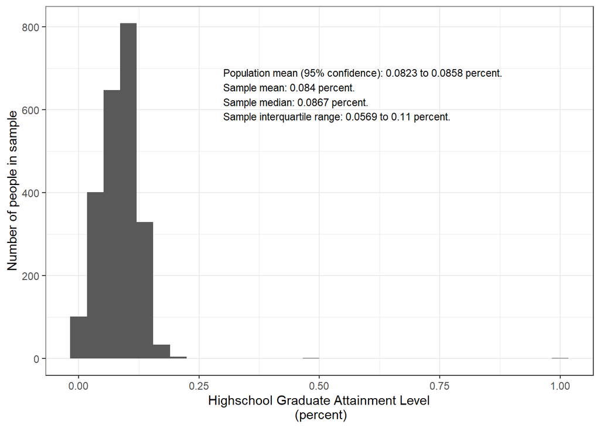

```r
hist <- ggplot(tract_data, aes(x = pct_hs_grad)) + geom_histogram()
hist +
  theme_bw() +
  scale_x_continuous(name = "Highschool Graduate Attainment Level\n (percent)") +
  scale_y_continuous(name = "Number of people in sample") +
  annotate ("text", x = 0.3, y = 700, size = 3,
            label = paste ("Population mean (95% confidence):",
                           prettyNum(pop_mean$conf.int[1], digits = 3),
                           "to",
                           prettyNum(pop_mean$conf.int[2], digits = 3),
                           "percent.",
                           "\nSample mean:",
                           prettyNum(mean(pct_hs_grad, na.rm = TRUE), digits = 3), "percent.",
                           "\nSample median:",
                           prettyNum(median(pct_hs_grad, na.rm = TRUE), digits = 3), "percent.",
                           "\nSample interquartile range:",
                           prettyNum(quantile(pct_hs_grad, na.rm = TRUE)["25%"], digits = 3),
                           "to",
                           prettyNum(quantile(pct_hs_grad, na.rm = TRUE)["75%"], digits = 3),
                           "percent."),
            hjust = 0, vjust = 1)
```

## Distribution of Categorical Variables

4. Majority race of the population (categorical) : maj_race_tract

```r
maj_race <- unique(maj_race_tract)
maj_race
```

```
## [1] "nh_black"    "hs_latino"   "no_majority" "nh_white"    "nh_asian"
## [6] "other"
```

```r
nh_black <- t.test (maj_race_tract == maj_race[1])
hs_latino <- t.test (maj_race_tract == maj_race[2])
no_majority <- t.test (maj_race_tract == maj_race[3])
nh_white <- t.test (maj_race_tract == maj_race[4])
nh_asian <- t.test (maj_race_tract == maj_race[5])
other <- t.test (maj_race_tract == maj_race[6])

shares <- tibble(MajorityRace = c("Black (not Hispanic/Latino)",
                            "Hispanic/Latino",
                            "No Majority",
                            "White (not Hispanic/Latino)",
                            "Asian (not Hispanic/Latino)",
                            "Other"),
                 `Share` = c(nh_black$estimate,
                             hs_latino$estimate,
                             no_majority$estimate,
                             nh_white$estimate,
                             nh_asian$estimate,
                             other$estimate),
                 Low = c(nh_black$conf.int[1],
                         hs_latino$conf.int[1],
                         no_majority$conf.int[1],
                         nh_white$conf.int[1],
                         nh_asian$conf.int[1],
                         other$conf.int[1]),
                 High = c(nh_black$conf.int[2],
                         hs_latino$conf.int[2],
                         no_majority$conf.int[2],
                         nh_white$conf.int[2],
                         nh_asian$conf.int[2],
                         other$conf.int[2]))
shares
```

```
## # A tibble: 6 x 4
##   MajorityRace                   Share       Low    High
##   <chr>                          <dbl>     <dbl>   <dbl>
## 1 Black (not Hispanic/Latino) 0.0226    0.0166   0.0286
## 2 Hispanic/Latino             0.462     0.442    0.482
## 3 No Majority                 0.230     0.213    0.247
## 4 White (not Hispanic/Latino) 0.232     0.215    0.249
## 5 Asian (not Hispanic/Latino) 0.0529    0.0438   0.0619
## 6 Other                       0.000853 -0.000329 0.00203
```

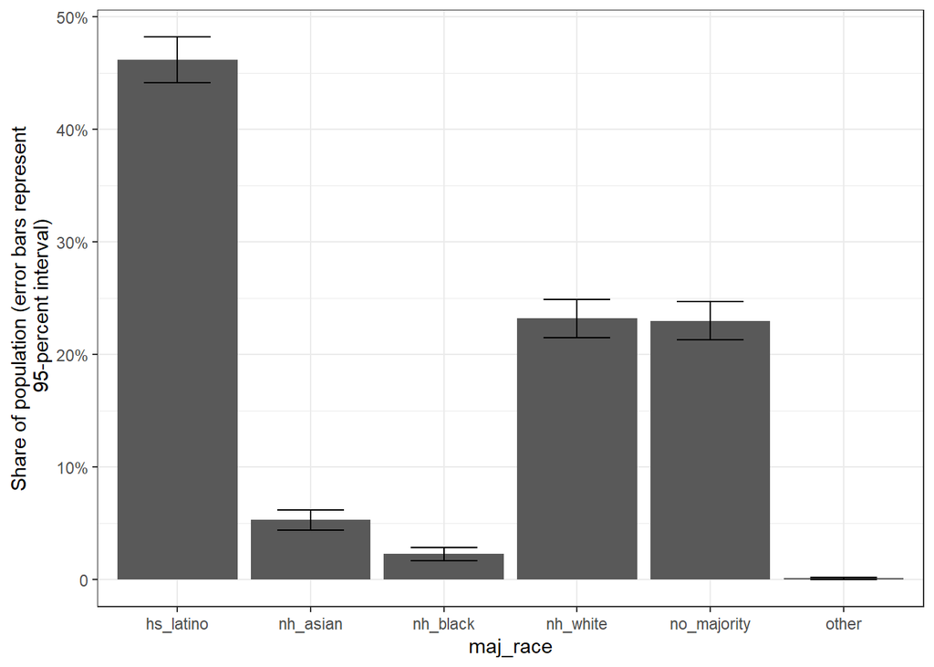

```r
ggplot(shares, aes(x = maj_race, y = Share, ymin = Low, ymax = High)) +
  geom_bar(stat = "identity") +
  geom_errorbar(width = 0.5) +
  theme_bw() +
  scale_y_continuous(name = "Share of population (error bars represent\n 95-percent interval)",
                  breaks = c(0, 0.1, 0.2, 0.3, 0.4, 0.5),
                  labels = c("0", "10%", "20%", "30%", "40%", "50%"))
```

5. Whether the majority of the population in the tract is foreign born or not(categorical): maj_foreign

```r
foreign_born <- unique(maj_foreign)
foreign_born
```

```
## [1] FALSE  TRUE    NA
```

I can see that there are two possible values (TRUE and FALSE) for my foreign born variable. I conduct a t-test for these two values separately to calculate the confidence interval for them and then organize those results into a dataframe.Then, I illustrate the results in a plot just like the one above.

```r
true <- t.test(maj_foreign==foreign_born[1])
true
```

```
##
##  One Sample t-test
##
## data:  maj_foreign == foreign_born[1]
## t = 132.56, df = 2326, p-value < 2.2e-16
## alternative hypothesis: true mean is not equal to 0
## 95 percent confidence interval:
##  0.8700477 0.8961749
## sample estimates:
## mean of x
## 0.8831113
```

```r
false<- t.test(maj_foreign==foreign_born[2])
false
```

```
##
##  One Sample t-test
##
## data:  maj_foreign == foreign_born[2]
## t = 17.546, df = 2326, p-value < 2.2e-16
## alternative hypothesis: true mean is not equal to 0
## 95 percent confidence interval:
##  0.1038251 0.1299523
## sample estimates:
## mean of x
## 0.1168887
```

```r
table2 <- tibble(foreign_born= c("TRUE","FALSE"),
    Foreign =c(true$estimate,false$estimate),
    Low =c(true$conf.int[1],false$conf.int[1]),
    High =c(true$conf.int[2],false$conf.int[2]))
table2
```

```
## # A tibble: 2 x 4
##   foreign_born Foreign   Low  High
##   <chr>          <dbl> <dbl> <dbl>
## 1 TRUE           0.883 0.870 0.896
## 2 FALSE          0.117 0.104 0.130
```

[figure not shown]

```r
ggplot(table2, aes(x= c("Majority foreign born", "Minority foreign born"),
                   y= Foreign, ymin= Low, ymax=High)) +
                  geom_bar(stat="identity") +
                  geom_errorbar(width = 0.5) +
  theme_bw() +
  scale_y_continuous(name= "Share of population (error bars represent \n 95 percent confidence interval )",
                     breaks=c(0,0.1,0.2,0.3,0.4,0.5),
                     labels=c("0","10%","20%","30%","40%","50%"))
```